# R Notebook

# Chapter 12 Robust summaries

```r
library(tidyverse)
library(dslabs)
```

## 12.1 Outliers

Outliers : common in data science

How do we distinguish an outlier from measurements that were too big or too small simply due to expected variability?

collecting demography data for a group of males

```r
library(dslabs)
data(outlier_example)
str(outlier_example)
```

```
 num [1:500] 5.59 5.8 5.54 6.15 5.83 5.54 5.87 5.93 5.89 5.67 ...
```

heights are usually well approximated by a normal distribution >>> summarizes the data with average and standard deviation

```r
mean(outlier_example)
```

```
[1] 6.10382
```

```r
sd(outlier_example)
```

```
[1] 7.796558
```

the standard deviation is over 7 inches 95% of this population will have heights between -9.489, 21.697 feet, which does not make sense

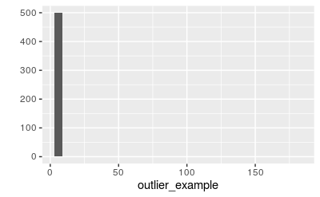

```r
qplot(outlier_example)
```

at least one value that is nonsensical

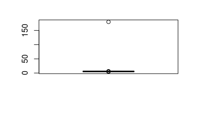

```r
boxplot(outlier_example)
```

## 12.2 Median

When we have an outlier like this, the average can become very large.

median-half the values are smaller and the other half are bigger- is robust to such outliers.

```r
median(outlier_example)
```

```
[1] 5.74
```

## 12.3 The inter quartile range (IQR)

box in boxplots: defined by first and third quartile 50% of the data is within this range IQR: Difference btwn 3rd and 1st quartile IQR / 1.349 approximates the standard deviation of the data had an outlier not been present.

```r
IQR(outlier_example) / 1.349
```

```
[1] 0.2446256
```

## 12.4 Tukey’s definition of an outlier

points falling outside the whiskers of the boxplot are referred to as outliers. The top whisker ends at the 75th percentile plus 1.5IQR. the bottom whisker ends at the 25th percentile minus 1.5IQR.

```r
q3 <- qnorm(0.75)
q1 <- qnorm(0.25)
iqr <- q3 - q1
r <- c(q1 - 1.5*iqr, q3 + 1.5*iqr)
r
```

```
[1] -2.697959  2.697959
```

if we have 1000 data points that are normally distributed, we expect to see about 7 outside of this range. But these would not be outliers since we expect to see them under the typical variation.

If we want an outlier to be rarer, we can increase the 1.5 to a larger number. 3: far out outliers. With a normal distribution, 100% of the data falls in this interval

can be controlled by the ‘outlier.size’ argument in ‘geom_boxplot’

```r
max_height <- quantile(outlier_example, 0.75) + 3*IQR(outlier_example)
max_height
```

```
 75%
6.91
```

data is in fact normally distributed as expected:

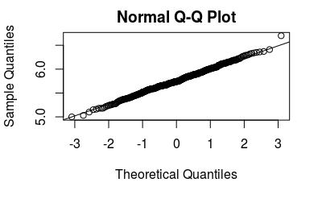

```r
x <- outlier_example[outlier_example < max_height]
qqnorm(x)
qqline(x)
```

## 12.5 Median Absolute Deviation

median absolute deviation (MAD) : compute the median, then for each value we compute the distance btwn that value and the median. MAD: median of distances.

needs to be multiplied by 1.4826 to assure it approximates the actual standard deviation.

function ‘mad’: has this correction

```r
mad(outlier_example)
```

```
[1] 0.237216
```

## 12.6 Exercises

```r
install.packages("HistData")
```

```r
library(HistData)
data(Galton)
x <- Galton$child
```

1. Compute the average and median of these data.

```r
mean(x)
```

```
[1] 68.08847
```

```r
median(x)
```

```
[1] 68.2
```

2. Compute the median and median absolute deviation of these data.

```r
median(x)
```

```
[1] 68.2
```

```r
mad(x)
```

```
[1] 2.9652
```

3. Now suppose Galton made a mistake when entering the first value and forgot to use the decimal point. You can imitate this error by typing:

```r
x_with_error <- x
x_with_error[1] <- x_with_error[1]*10
```

How many inches does the average grow after this mistake?

```r
mean(x_with_error)-mean(x)
```

```
[1] 0.5983836
```

4. How many inches does the SD grow after this mistake?

```r
sd(x_with_error)-sd(x)
```

```
[1] 15.6746
```

5. How many inches does the median grow after this mistake?

```r
median(x_with_error)-median(x)
```

```
[1] 0
```

6. How many inches does the MAD grow after this mistake?

```r
mad(x_with_error)-mad(x)
```

```
[1] 0
```

7. How could you use exploratory data analysis to detect that an error was made?

A. Since it is only one value out of many, we will not be able to detect this.

B. We would see an obvious shift in the distribution.

**C. A boxplot, histogram, or qq-plot would reveal a clear outlier.**

D. A scatter plot would show high levels of measurement error.

8. How much can the average accidentally grow with mistakes like this? Write a function called error_avg that takes a value k and returns the average of the vector x after the first entry changed to k. Show the results for k=10000 and k=-10000.

## 12.7 Case study: self-reported student heights

```r
library(dslabs)
data("reported_heights")
head(reported_heights)
```

|  | time_stamp | sex | height |
| --- | --- | --- | --- |
| 1 | 2014-09-02 13:40:36 | Male | 75 |
| 2 | 2014-09-02 13:46:59 | Male | 70 |
| 3 | 2014-09-02 13:59:20 | Male | 68 |
| 4 | 2014-09-02 14:51:53 | Male | 74 |
| 5 | 2014-09-02 15:16:15 | Male | 61 |
| 6 | 2014-09-02 15:16:16 | Female | 65 |

```r
reported_heights <- reported_heights %>%
  mutate(original_heights = height, height = as.numeric(height))
```

```
NAs introduced by coercion
```

height: character vector: some of the heights were not numbers; warning

```r
reported_heights %>%
  filter(is.na(height)) %>%
  head()
```

|  | time_stamp | sex | height | original_heights |
| --- | --- | --- | --- | --- |
| 1 | 2014-09-02 15:16:28 | Male | NA | 5' 4" |
| 2 | 2014-09-02 15:16:37 | Female | NA | 165cm |
| 3 | 2014-09-02 15:16:52 | Male | NA | 5'7 |
| 4 | 2014-09-02 15:16:56 | Male | NA | >9000 |
| 5 | 2014-09-02 15:16:56 | Male | NA | 5'7" |
| 6 | 2014-09-02 15:17:09 | Female | NA | 5'3" |

```r
reported_heights <- filter(reported_heights, !is.na(height))
```

The average and standard deviation are different from the median and MAD

```r
reported_heights %>%
  group_by(sex) %>%
  summarize(average = mean(height), sd = sd(height),
            median = median(height), MAD = mad(height))
```

| sex | average | sd | median | MAD |
| --- | --- | --- | --- | --- |
| Female | 63.40779 | 27.93076 | 64.2 | 4.046164 |
| Male | 103.37705 | 529.86240 | 70.0 | 4.447800 |

use function ‘arrange’ to look at the largest values

```r
reported_heights %>%
  arrange(desc(height)) %>%
  top_n(10, height)
```

| time_stamp | sex | height | original_heights |
| --- | --- | --- | --- |
| 2014-09-03 23:55:37 | Male | 11111 | 11111 |
| 2016-04-10 22:45:49 | Male | 10000 | 10000 |
| 2015-08-10 03:10:01 | Male | 684 | 684 |
| 2015-02-27 18:05:06 | Male | 612 | 612 |
| 2014-09-02 15:16:41 | Male | 511 | 511 |
| 2014-09-07 20:53:43 | Male | 300 | 300 |
| 2014-11-28 12:18:40 | Male | 214 | 214 |
| 2017-04-03 16:16:57 | Male | 210 | 210 |
| 2015-11-24 10:39:45 | Male | 192 | 192 |
| 2014-12-26 10:00:12 | Male | 190 | 190 |

[output cut: 1 more lines]

Some are inches and some are centimeters!

```r
max_height <- quantile(reported_heights$height, .75) + 3*IQR(reported_heights$height)
min_height <- quantile(reported_heights$height, .25) - 3*IQR(reported_heights$height)
c(min_height, max_height)
```

```
25% 75%
 44  93
```

```r
reported_heights %>%
  filter(!between(height, min_height, max_height)) %>%
  select(original_heights) %>%
  head(n=10)
```

|  | original_heights |
| --- | --- |
| 1 | 6 |
| 2 | 5.3 |
| 3 | 511 |
| 4 | 6 |
| 5 | 2 |
| 6 | 5.25 |
| 7 | 5.5 |
| 8 | 11111 |
| 9 | 6 |
| 10 | 6.5 |

2 mistakes : entires in centimeters turn out to be too large, entires of the form x.y(feet.inches) too small. some could be entries in meters we’ll later learn for correcting these values and converting them into inches